# Reproducible Research: Peer Assessment 1

Rama Mohan D

Friday, October 17, 2014

All code chunks visibility setting globally -

opts_chunk$set(echo=TRUE)

This document describes the analysis of data from a personal activity monitoring device. The data consists of two months of data from an anonymous individual collected during the months of October and November, 2012 and include the number of steps taken in 5 minute intervals each day.

**Loading and preprocessing the data:**

First read the data csv file using read.csv function and load into activitydata variable. For this datafile which is located need to be set as working directory.

```r
setwd("C:/my files/Coursera Learning/R_Programming Files/RR Project1/repdata-data-activity")
activitydata <- read.csv("activity.csv", colClasses=c("integer", "Date", "integer"))
```

**Basic summary:**

Let’s have look at summary of activity data

```r
str(activitydata)
```

```
## 'data.frame':    17568 obs. of  3 variables:
##  $ steps   : int  NA NA NA NA NA NA NA NA NA NA ...
##  $ date    : Date, format: "2012-10-01" "2012-10-01" ...
##  $ interval: int  0 5 10 15 20 25 30 35 40 45 ...
```

```r
summary(activitydata)
```

```
##      steps            date               interval
##  Min.   :  0.0   Min.   :2012-10-01   Min.   :   0
##  1st Qu.:  0.0   1st Qu.:2012-10-16   1st Qu.: 589
##  Median :  0.0   Median :2012-10-31   Median :1178
##  Mean   : 37.4   Mean   :2012-10-31   Mean   :1178
##  3rd Qu.: 12.0   3rd Qu.:2012-11-15   3rd Qu.:1766
##  Max.   :806.0   Max.   :2012-11-30   Max.   :2355
##  NA's   :2304
```

**What is mean total number of steps taken per day?**

First calculate the total number of steps each day by excluding the missing values and also calculation of mean totalsteps and median of total steps.

```r
total_steps <- tapply(activitydata$steps, activitydata$date, sum, na.rm=T)
meanstepday <- mean(total_steps); medianstepday <- median(total_steps)
```

Mean of Total steps per each day

```r
meanstepday
```

```
## [1] 9354
```

Median of Total steps per each day

```r
medianstepday
```

```
## [1] 10395
```

Histogram of the total number of steps taken each day

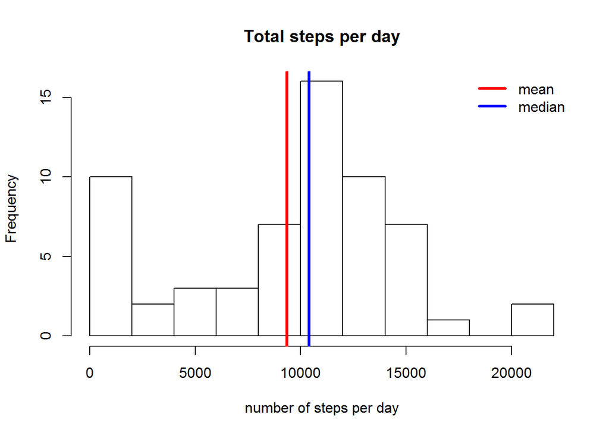

```r
hist(total_steps, breaks=11, xlab="number of steps per day",main="Total steps per day")
abline(v=meanstepday, col="red", lwd=3); abline(v=medianstepday, col="blue", lwd=3)
legend(x="topright", legend=c("mean","median"), col=c("red","blue"), bty="n", lwd=3)
```

**What is the average daily activity pattern?**

Let’s look at the average number of steps per 5 minute period, we can use the aggregate function to calculate the mean of each interval.

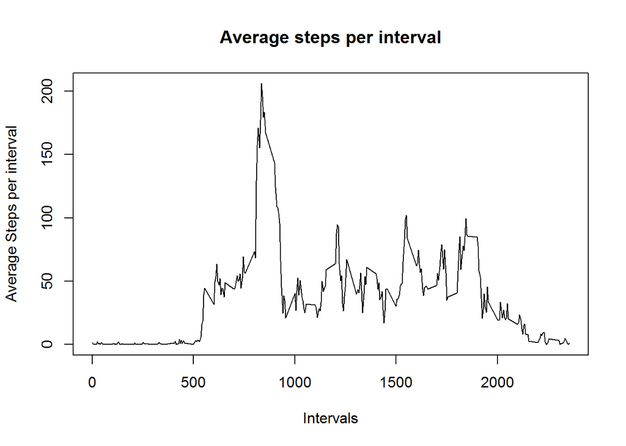

```r
#Make a time series plot (i.e. type = "l") of the 5-minute interval (x-axis) and the average number of steps taken, averaged across all days (y-axis)
average_interval <- aggregate(steps ~ interval, activitydata, mean)
plot(average_interval, type = "l", xlab="Intervals", ylab="Average Steps per interval", main="Average steps per interval")
```

Which 5-minute interval, on average across all the days in the dataset, contains the maximum number of steps?

```r
average_interval$interval[which.max(average_interval$steps)]
```

```
## [1] 835
```

**Imputing missing values:**

Calculate and report the total number of missing values in the dataset (i.e. the total number of rows with NAs)

```r
sum(is.na(activitydata$steps))
```

```
## [1] 2304
```

```r
print(missing_dates <- unique(activitydata[is.na(activitydata$steps), ]$date))
```

```
## [1] "2012-10-01" "2012-10-08" "2012-11-01" "2012-11-04" "2012-11-09"
## [6] "2012-11-10" "2012-11-14" "2012-11-30"
```

```r
sapply(missing_dates, function(X) sum(is.na(activitydata[activitydata$date == X, ]$steps)))
```

```
## [1] 288 288 288 288 288 288 288 288
```

Devise a strategy for filling in all of the missing values in the dataset. The strategy does not need to be sophisticated. For example, you could use the mean/median for that day, or the mean for that 5-minute interval,etc

NA replaced by mean in 5 min interval (average daily activity pattern)

```r
completed_data <- activitydata
for (X in missing_dates) completed_data[completed_data$date == X, ]$steps = average_interval$steps
completed_daily_steps <- with(completed_data, tapply(steps, date, sum, na.rm = T))
head(completed_daily_steps)
```

```
## 2012-10-01 2012-10-02 2012-10-03 2012-10-04 2012-10-05 2012-10-06
##      10766        126      11352      12116      13294      15420
```

Make a histogram of the total number of steps taken each day and Calculate and report the mean and median total number of steps taken per day. Do these values differ from the estimates from the first part of the assignment? What is the impact of imputing missing data on the estimates of the total daily number of steps?

```r
meanstepday_cmp <- mean(completed_daily_steps);
meanstepday_cmp
```

```
## [1] 10766
```

```r
medianstepday_cmp <- median(completed_daily_steps)
medianstepday_cmp
```

```
## [1] 10766
```

The Histogram is

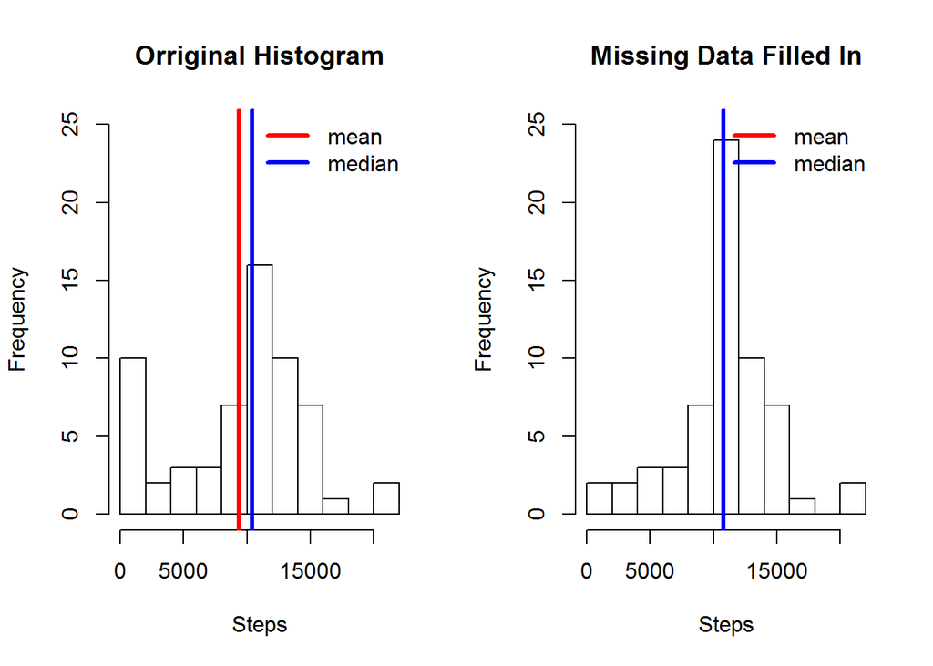

```r
par(mfrow = c(1, 2))
hist(total_steps, breaks = 10, xlab = "Steps", main = "Orriginal Histogram", ylim = c(0, 25))
abline(v=meanstepday, col="red", lwd=3); abline(v=medianstepday, col="blue", lwd=3)
legend(x="topright", legend=c("mean","median"), col=c("red","blue"), bty="n", lwd=3)
hist(completed_daily_steps, breaks = 10, xlab = "Steps", main = "Missing Data Filled In", ylim = c(0, 25))
abline(v=meanstepday_cmp, col="red", lwd=3); abline(v=medianstepday_cmp, col="blue", lwd=3)
legend(x="topright", legend=c("mean","median"), col=c("red","blue"), bty="n", lwd=3)
```

**Are there differences in activity patterns between weekdays and weekends?**

Create a new factor variable in the dataset with two levels - “weekday” and “weekend” indicating whether a given date is a weekday or weekend day.

```r
require(plyr)
activitydata$Weekend <- weekdays(activitydata$date) == "Saturday" | weekdays(activitydata$date) == "Sunday"
activitydata$Weekend <- factor(activitydata$Weekend, levels = c(F, T), labels = c("Weekday", "Weekend"))
```

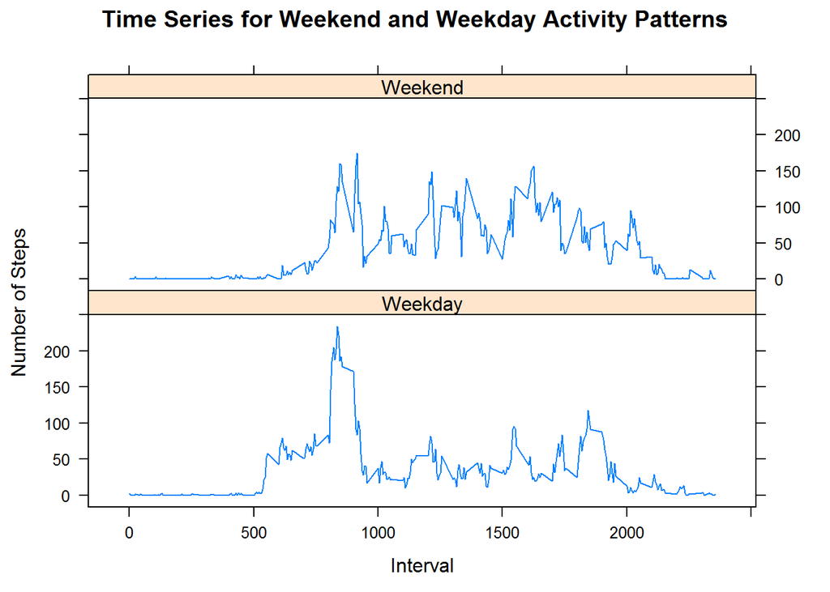

```r
activity <- ddply(activitydata, .(interval, Weekend), summarize, steps = mean(steps, na.rm = T))
library(lattice)
xyplot(steps ~ interval | Weekend, activity, type = "l", layout = c(1, 2), ylab = "Number of Steps", xlab = "Interval", main = "Time Series for Weekend and Weekday Activity Patterns")
```